# How Funnel Analysis Improves Marketing Decisions

Author

Mengyao Ma

Published

May 10, 2026

Marketing Analytics

# From Ad Clicks to Customer Value

How Funnel Analysis Improves Marketing Decisions

Mengyao Ma

Marketing / Analytics Presentation

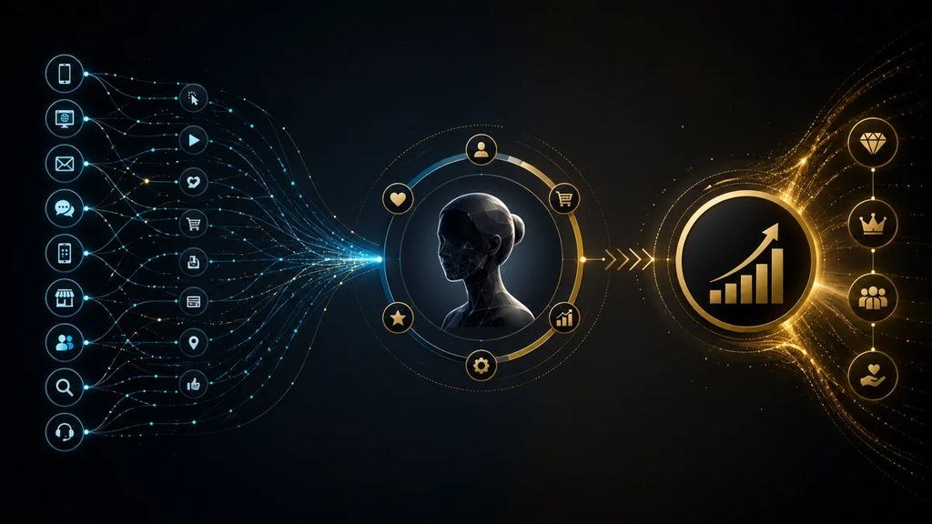

## The click problem: activity can look like growth

Visible acquisition metrics are useful, but they often hide weak downstream economics.

### Why top-of-funnel metrics can mislead

- High CTR or low CPC can make a campaign look efficient before we know whether those users activate, buy, or return.
- A campaign may generate traffic but still bring in low-value cohorts with weak retention and poor payback.
- The strategic question is not only who clicked, but who became valuable over time.

### Decision shift

Clicks answer:

Who reacted?

Funnel analysis answers:

Who activated, retained, and created value?

Better marketing decisions come from linking behavior to economics, not from maximizing the easiest metric.

## A strong funnel connects behavior to economics

The goal is to find the most valuable bottleneck, not simply the most visible one.

Reach

qualified audience

›

Click

intent signal

›

Activate

first-value moment

›

Purchase

monetization

›

Retain

CLV / payback

### Three diagnostic questions

- Where is the biggest leak in the funnel?
- How much customer value is lost at that stage?
- Which intervention creates the highest economic impact?

### Managerial implication

Teams stop asking only how to buy more traffic.  
They start asking where budget, CRM, product, or creative improvements will generate more profitable growth.

## Real example: Starbucks Rewards as a customer-value funnel

A practical case where marketing moves beyond one transaction toward repeat behavior and measurable loyalty.

### Funnel logic

Campaign or offer brings the customer into the app or Rewards program.  
The first purchase creates a measurable starting point.  
Personalized offers and rewards encourage repeat visits and stronger lifetime value.

33.8M

U.S. 90-day active Rewards members in Q4 FY2024

+4%

year-over-year growth in that quarter

$36.2B

FY2024 consolidated net revenue

### Why the example matters

The point is not just one order. Starbucks uses loyalty to move customers into a repeatable relationship that can be measured, managed, and grown over time.

Source note: Starbucks Q4 FY2024 results and FY2024 annual report.

## Decision example: the best lever may not be more clicks

Illustrative funnel math shows why retention can be more valuable than pure traffic growth.

100k

Clicks

›

12k

Sign-ups

›

7k

Activated

›

3.2k

First purchases

›

1.6k

Retained

### Option A: buy more clicks

More scale, but also more media cost. Weak users may still drop out later.

### Option B: improve activation

More users reach the first value moment, often creating stronger downstream performance.

### Option C: improve retention

Often the highest-value lever because repeat revenue rises without paying again for acquisition.

The funnel changes the question from “How do we get more visitors?” to “Which stage creates the most incremental customer value?”

## Takeaway: optimize for customer equity, not campaign activity

Funnel analysis becomes strategic when it guides where marketers should act next.

### 1. Clicks are a signal, not the destination

They matter only when they predict activation, purchase, retention, and value.

### 2. Rank bottlenecks by value loss

A leak near retention can be more expensive than a leak near acquisition.

### 3. Segmentation makes the funnel strategic

Compare cohorts by channel, creative, region, offer, and customer type.

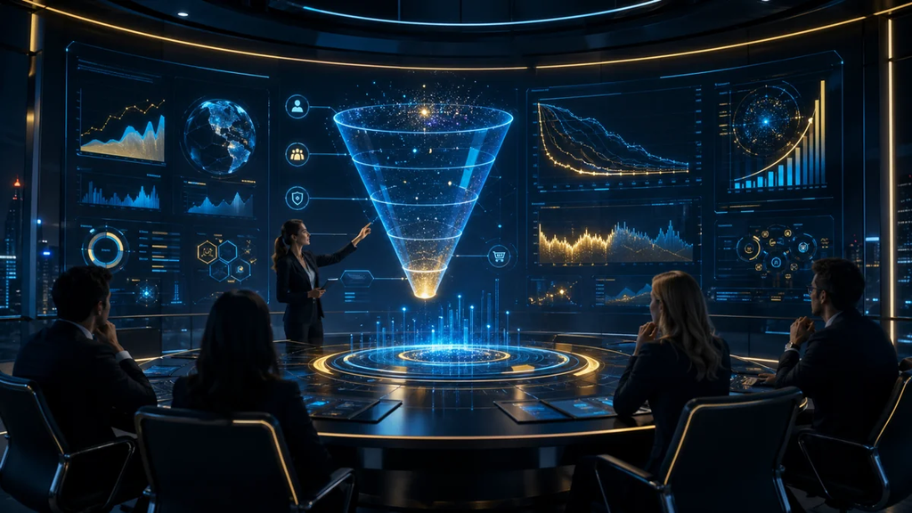

Final line

The best marketers do not stop at “what converted?” They ask “what created customers worth keeping?”